# Preparacion3parcial#1

2025-10-28

## Cargar la data

```r
library(tidyverse)
df <- data.frame(
  volumen = c(0.01, 0.06, 0.58, 2.24, 15.55, 276.02),
  porcentaje_ceniza = c(3.32, 4.05, 5.69, 7.06, 8.17, 9.36)
)
```

## Punto 1

Calcule la recta de mínimos cuadrados para predecir el porcentaje de ceniza (y) a partir del volumen (x). Grafique los residuos contra los valores ajustados. ¿El modelo lineal parece adecuado? Explique

```r
## y es la que quieres predecir  y X con la que estimas
modelo1 <- lm(  porcentaje_ceniza~ volumen, data = df)
print(modelo1)
```

```
##
## Call:
## lm(formula = porcentaje_ceniza ~ volumen, data = df)
##
## Coefficients:
## (Intercept)      volumen
##     5.57646      0.01423
```

```r
print("y= 5.57646 + x*0.01423")
```

```
## [1] "y= 5.57646 + x*0.01423"
```

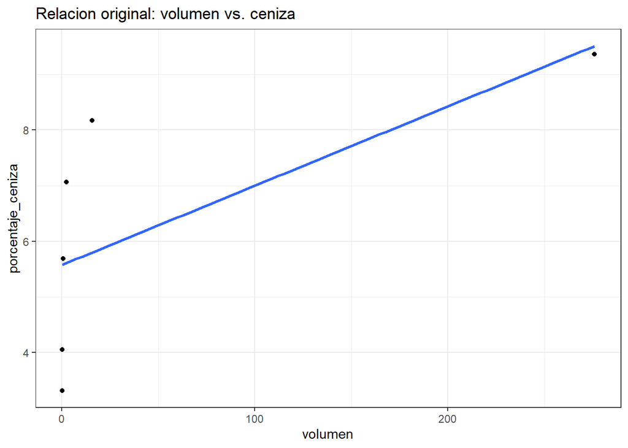

```r
df %>%
ggplot(aes( volumen, porcentaje_ceniza)) +
  geom_point() +
  geom_smooth(method = "lm", se = FALSE) +
  labs(title = "Relacion original: volumen vs. ceniza")+
  theme_bw()
```

El modelo no sigue un modelo lineal por lo que tendremos que hacer una tranformacion

## Punto 2

Calcule la recta de mínimos cuadrados para predecir el porcentaje de ceniza a partir del logaritmo natural del volumen. Grafique los residuos contra los valores ajustados. ¿El modelo lineal parece adecuado? Explique.

```r
modelo2 <- lm(porcentaje_ceniza ~ log(volumen), data = df)

# Obtener coeficientes
coef(modelo2)
```

```
##  (Intercept) log(volumen)
##    6.1484169    0.6288792
```

```r
print( "ŷ = 6.1484169    + log(x)*0.6288792" )
```

```
## [1] "ŷ = 6.1484169    + log(x)*0.6288792"
```

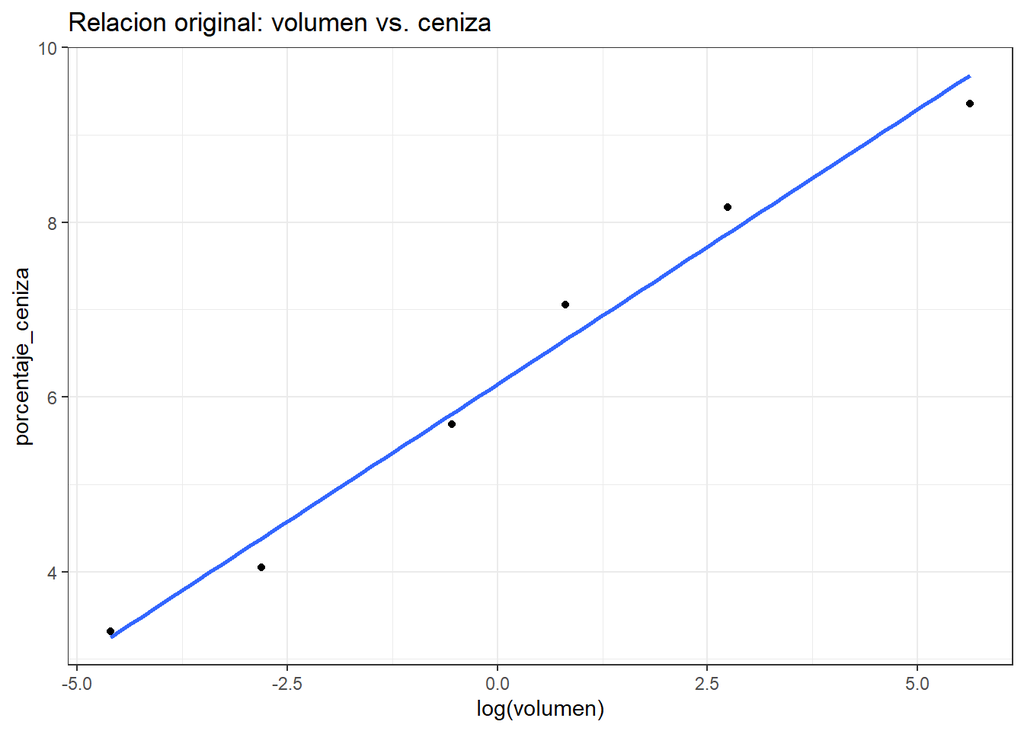

```r
df %>%
ggplot(aes( log(volumen), porcentaje_ceniza)) +
  geom_point() +
  geom_smooth(method = "lm", se = FALSE) +
  labs(title = "Relacion original: volumen vs. ceniza")+
  theme_bw()
```

Se ve una clara relacion lineal por lo que este modelo es el adecuado

## Punto 3

Calcule la recta de mínimos cuadrados para predecir el porcentaje de ceniza a partir de la raíz cuadrada del volumen. Grafique los residuos contra los valores ajustados. ¿El modelo lineal parece adecuado? Explique.

```r
modelo3 <- lm(porcentaje_ceniza ~ sqrt(volumen), data = df)

# Obtener coeficientes
coef(modelo3)
```

```
##   (Intercept) sqrt(volumen)
##     5.1716196     0.2858451
```

```r
print("y=5.1716196  +   sqrt(x)*0.2858451")
```

```
## [1] "y=5.1716196  +   sqrt(x)*0.2858451"
```

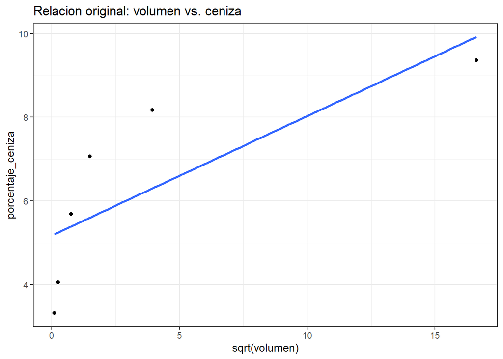

```r
df %>%
ggplot(aes( sqrt(volumen), porcentaje_ceniza)) +
  geom_point() +
  geom_smooth(method = "lm", se = FALSE) +
  labs(title = "Relacion original: volumen vs. ceniza")+
  theme_bw()
```

El modelo no sigue un modelo lineal por lo que tendremos que hacer una tranformacion esta transformacion no nos sirve

## Punto 4

Utilizando el modelo más adecuado, pronostique el porcentaje de ceniza para partículas con un volumen de 50 m3.

Por los resultados es evidente que el modelo ligaritmico es el que menos residuos aleatorios presenta

```r
pronostico_puntual <- predict(modelo2, newdata = data.frame(volumen = 50))
pronostico_puntual
```

```
##        1
## 8.608607
```

## Punto 5

Utilizando el modelo más adecuado, construya un intervalo de confianza de 95% para la media de un porcentaje de ceniza para partículas con un volumen de 50 m3.

```r
x <- c(0.01, 0.06, 0.58, 2.24, 15.55, 276.02)
y <- c(3.32, 4.05, 5.69, 7.06, 8.17, 9.36)
n <- length(x)

# Modelo logarítmico (por verificación)
lm_b <- lm(y ~ log(x))

# Coeficientes CORRECTOS del modelo2
b0 <- 6.1484169
b1 <- 0.6288792

# Punto de interés
x0 <- 50
z0 <- log(x0)

# valores z_i
z <- log(x)
z_bar <- mean(z)
Szz <- sum((z - z_bar)^2)

# residuos
res <- resid(lm_b)
RSS <- sum(res^2)
s <- sqrt(RSS / (n - 2))

# predicción puntual
yhat0 <- b0 + b1 * z0

# error estándar de la media predicha
SE_mean <- s * sqrt(1/n + ((z0 - z_bar)^2) / Szz)

# t crítico (df = n-2)
t_crit <- qt(0.975, df = n - 2)

# intervalo de confianza 95% para la media
lower <- yhat0 - t_crit * SE_mean
upper <- yhat0 + t_crit * SE_mean

cat("yhat0 =", yhat0, "\nSE_mean =", SE_mean, "\nt_crit =", t_crit,
    "\nIC95% = [", lower, ",", upper, "]\n")
```

```
## yhat0 = 8.608607
## SE_mean = 0.2100649
## t_crit = 2.776445
## IC95% = [ 8.025373 , 9.19184 ]
```

```r
# Para intervalo de confianza de la MEDIA:
ic_media <- predict(modelo2, newdata = data.frame(volumen = 50),
                   interval = "confidence", level = 0.95)

print(ic_media)
```

```
##        fit      lwr     upr
## 1 8.608607 8.025373 9.19184
```